# Data Science with Capstone (Real Estate Project)

## Data Import & Preparations

```python
#  Import the dataset
import pandas as pd
import numpy as np
import matplotlib.pyplot as plt
import seaborn as sns
```

```python
df_test=pd.read_csv('testing.csv')
```

```python
df_train=pd.read_csv('training.csv')
```

```python
df_test.head()
```

|  | UID | BLOCKID | SUMLEVEL | COUNTYID | STATEID | state | state_ab | city | place | type | ... | female_age_mean | female_age_median | female_age_stdev | female_age_sample_weight | female_age_samples | pct_own | married | married_snp | separated | divorced |
| --- | --- | --- | --- | --- | --- | --- | --- | --- | --- | --- | --- | --- | --- | --- | --- | --- | --- | --- | --- | --- | --- |
| 0 | 255504 | NaN | 140 | 163 | 26 | Michigan | MI | Detroit | Dearborn Heights City | CDP | ... | 34.78682 | 33.75000 | 21.58531 | 416.48097 | 1938.0 | 0.70252 | 0.28217 | 0.05910 | 0.03813 | 0.14299 |
| 1 | 252676 | NaN | 140 | 1 | 23 | Maine | ME | Auburn | Auburn City | City | ... | 44.23451 | 46.66667 | 22.37036 | 532.03505 | 1950.0 | 0.85128 | 0.64221 | 0.02338 | 0.00000 | 0.13377 |
| 2 | 276314 | NaN | 140 | 15 | 42 | Pennsylvania | PA | Pine City | Millerton | Borough | ... | 41.62426 | 44.50000 | 22.86213 | 453.11959 | 1879.0 | 0.81897 | 0.59961 | 0.01746 | 0.01358 | 0.10026 |
| 3 | 248614 | NaN | 140 | 231 | 21 | Kentucky | KY | Monticello | Monticello City | City | ... | 44.81200 | 48.00000 | 21.03155 | 263.94320 | 1081.0 | 0.84609 | 0.56953 | 0.05492 | 0.04694 | 0.12489 |
| 4 | 286865 | NaN | 140 | 355 | 48 | Texas | TX | Corpus Christi | Edroy | Town | ... | 40.66618 | 42.66667 | 21.30900 | 709.90829 | 2956.0 | 0.79077 | 0.57620 | 0.01726 | 0.00588 | 0.16379 |

5 rows × 80 columns

```python
df_train.head()
```

|  | UID | BLOCKID | SUMLEVEL | COUNTYID | STATEID | state | state_ab | city | place | type | ... | female_age_mean | female_age_median | female_age_stdev | female_age_sample_weight | female_age_samples | pct_own | married | married_snp | separated | divorced |
| --- | --- | --- | --- | --- | --- | --- | --- | --- | --- | --- | --- | --- | --- | --- | --- | --- | --- | --- | --- | --- | --- |
| 0 | 267822 | NaN | 140 | 53 | 36 | New York | NY | Hamilton | Hamilton | City | ... | 44.48629 | 45.33333 | 22.51276 | 685.33845 | 2618.0 | 0.79046 | 0.57851 | 0.01882 | 0.01240 | 0.08770 |
| 1 | 246444 | NaN | 140 | 141 | 18 | Indiana | IN | South Bend | Roseland | City | ... | 36.48391 | 37.58333 | 23.43353 | 267.23367 | 1284.0 | 0.52483 | 0.34886 | 0.01426 | 0.01426 | 0.09030 |
| 2 | 245683 | NaN | 140 | 63 | 18 | Indiana | IN | Danville | Danville | City | ... | 42.15810 | 42.83333 | 23.94119 | 707.01963 | 3238.0 | 0.85331 | 0.64745 | 0.02830 | 0.01607 | 0.10657 |
| 3 | 279653 | NaN | 140 | 127 | 72 | Puerto Rico | PR | San Juan | Guaynabo | Urban | ... | 47.77526 | 50.58333 | 24.32015 | 362.20193 | 1559.0 | 0.65037 | 0.47257 | 0.02021 | 0.02021 | 0.10106 |
| 4 | 247218 | NaN | 140 | 161 | 20 | Kansas | KS | Manhattan | Manhattan City | City | ... | 24.17693 | 21.58333 | 11.10484 | 1854.48652 | 3051.0 | 0.13046 | 0.12356 | 0.00000 | 0.00000 | 0.03109 |

5 rows × 80 columns

```python
# shape of data
df_train.shape
```

```
(27321, 80)
```

```python
df_test.shape
```

```
(11709, 80)
```

```python
# train data columns
df_train.columns
```

```
Index(['UID', 'BLOCKID', 'SUMLEVEL', 'COUNTYID', 'STATEID', 'state',
       'state_ab', 'city', 'place', 'type', 'primary', 'zip_code', 'area_code',
       'lat', 'lng', 'ALand', 'AWater', 'pop', 'male_pop', 'female_pop',
       'rent_mean', 'rent_median', 'rent_stdev', 'rent_sample_weight',
       'rent_samples', 'rent_gt_10', 'rent_gt_15', 'rent_gt_20', 'rent_gt_25',
       'rent_gt_30', 'rent_gt_35', 'rent_gt_40', 'rent_gt_50',
       'universe_samples', 'used_samples', 'hi_mean', 'hi_median', 'hi_stdev',
       'hi_sample_weight', 'hi_samples', 'family_mean', 'family_median',
       'family_stdev', 'family_sample_weight', 'family_samples',
       'hc_mortgage_mean', 'hc_mortgage_median', 'hc_mortgage_stdev',
       'hc_mortgage_sample_weight', 'hc_mortgage_samples', 'hc_mean',
       'hc_median', 'hc_stdev', 'hc_samples', 'hc_sample_weight',
       'home_equity_second_mortgage', 'second_mortgage', 'home_equity', 'debt',
       'second_mortgage_cdf', 'home_equity_cdf', 'debt_cdf', 'hs_degree',
       'hs_degree_male', 'hs_degree_female', 'male_age_mean',
       'male_age_median', 'male_age_stdev', 'male_age_sample_weight',
       'male_age_samples', 'female_age_mean', 'female_age_median',
       'female_age_stdev', 'female_age_sample_weight', 'female_age_samples',
       'pct_own', 'married', 'married_snp', 'separated', 'divorced'],
      dtype='object')
```

```python
# test data columns
df_test.columns
```

```
Index(['UID', 'BLOCKID', 'SUMLEVEL', 'COUNTYID', 'STATEID', 'state',
       'state_ab', 'city', 'place', 'type', 'primary', 'zip_code', 'area_code',
       'lat', 'lng', 'ALand', 'AWater', 'pop', 'male_pop', 'female_pop',
       'rent_mean', 'rent_median', 'rent_stdev', 'rent_sample_weight',
       'rent_samples', 'rent_gt_10', 'rent_gt_15', 'rent_gt_20', 'rent_gt_25',
       'rent_gt_30', 'rent_gt_35', 'rent_gt_40', 'rent_gt_50',
       'universe_samples', 'used_samples', 'hi_mean', 'hi_median', 'hi_stdev',
       'hi_sample_weight', 'hi_samples', 'family_mean', 'family_median',
       'family_stdev', 'family_sample_weight', 'family_samples',
       'hc_mortgage_mean', 'hc_mortgage_median', 'hc_mortgage_stdev',
       'hc_mortgage_sample_weight', 'hc_mortgage_samples', 'hc_mean',
       'hc_median', 'hc_stdev', 'hc_samples', 'hc_sample_weight',
       'home_equity_second_mortgage', 'second_mortgage', 'home_equity', 'debt',
       'second_mortgage_cdf', 'home_equity_cdf', 'debt_cdf', 'hs_degree',
       'hs_degree_male', 'hs_degree_female', 'male_age_mean',
       'male_age_median', 'male_age_stdev', 'male_age_sample_weight',
       'male_age_samples', 'female_age_mean', 'female_age_median',
       'female_age_stdev', 'female_age_sample_weight', 'female_age_samples',
       'pct_own', 'married', 'married_snp', 'separated', 'divorced'],
      dtype='object')
```

```python
df_train.describe()
```

|  | UID | BLOCKID | SUMLEVEL | COUNTYID | STATEID | zip_code | area_code | lat | lng | ALand | ... | female_age_mean | female_age_median | female_age_stdev | female_age_sample_weight | female_age_samples | pct_own | married | married_snp | separated | divorced |
| --- | --- | --- | --- | --- | --- | --- | --- | --- | --- | --- | --- | --- | --- | --- | --- | --- | --- | --- | --- | --- | --- |
| count | 27321.000000 | 0.0 | 27321.0 | 27321.000000 | 27321.000000 | 27321.000000 | 27321.000000 | 27321.000000 | 27321.000000 | 2.732100e+04 | ... | 27115.000000 | 27115.000000 | 27115.000000 | 27115.000000 | 27115.000000 | 27053.000000 | 27130.000000 | 27130.000000 | 27130.000000 | 27130.000000 |
| mean | 257331.996303 | NaN | 140.0 | 85.646426 | 28.271806 | 50081.999524 | 596.507668 | 37.508813 | -91.288394 | 1.295106e+08 | ... | 40.319803 | 40.355099 | 22.178745 | 544.238432 | 2208.761903 | 0.640434 | 0.508300 | 0.047537 | 0.019089 | 0.100248 |
| std | 21343.859725 | NaN | 0.0 | 98.333097 | 16.392846 | 29558.115660 | 232.497482 | 5.588268 | 16.343816 | 1.275531e+09 | ... | 5.886317 | 8.039585 | 2.540257 | 283.546896 | 1089.316999 | 0.226640 | 0.136860 | 0.037640 | 0.020796 | 0.049055 |
| min | 220342.000000 | NaN | 140.0 | 1.000000 | 1.000000 | 602.000000 | 201.000000 | 17.929085 | -165.453872 | 4.113400e+04 | ... | 16.008330 | 13.250000 | 0.556780 | 0.664700 | 2.000000 | 0.000000 | 0.000000 | 0.000000 | 0.000000 | 0.000000 |
| 25% | 238816.000000 | NaN | 140.0 | 29.000000 | 13.000000 | 26554.000000 | 405.000000 | 33.899064 | -97.816067 | 1.799408e+06 | ... | 36.892050 | 34.916670 | 21.312135 | 355.995825 | 1471.000000 | 0.502780 | 0.425102 | 0.020810 | 0.004530 | 0.065800 |
| 50% | 257220.000000 | NaN | 140.0 | 63.000000 | 28.000000 | 47715.000000 | 614.000000 | 38.755183 | -86.554374 | 4.866940e+06 | ... | 40.373320 | 40.583330 | 22.514410 | 503.643890 | 2066.000000 | 0.690840 | 0.526665 | 0.038840 | 0.013460 | 0.095205 |
| 75% | 275818.000000 | NaN | 140.0 | 109.000000 | 42.000000 | 77093.000000 | 801.000000 | 41.380606 | -79.782503 | 3.359820e+07 | ... | 43.567120 | 45.416670 | 23.575260 | 680.275055 | 2772.000000 | 0.817460 | 0.605760 | 0.065100 | 0.027488 | 0.129000 |
| max | 294334.000000 | NaN | 140.0 | 840.000000 | 72.000000 | 99925.000000 | 989.000000 | 67.074017 | -65.379332 | 1.039510e+11 | ... | 79.837390 | 82.250000 | 30.241270 | 6197.995200 | 27250.000000 | 1.000000 | 1.000000 | 0.714290 | 0.714290 | 1.000000 |

8 rows × 74 columns

```python
df_train.info()
```

```
<class 'pandas.core.frame.DataFrame'>
RangeIndex: 27321 entries, 0 to 27320
Data columns (total 80 columns):
 #   Column                       Non-Null Count  Dtype
---  ------                       --------------  -----
 0   UID                          27321 non-null  int64
 1   BLOCKID                      0 non-null      float64
 2   SUMLEVEL                     27321 non-null  int64
 3   COUNTYID                     27321 non-null  int64
 4   STATEID                      27321 non-null  int64
 5   state                        27321 non-null  object
 6   state_ab                     27321 non-null  object
 7   city                         27321 non-null  object
 8   place                        27321 non-null  object
 9   type                         27321 non-null  object
```

[output cut: 72 more lines]

## Figure out the Primary key and look for the requirement of indexing

```python
# make UID as index
df_test.set_index(keys=['UID'],inplace=True)
```

```python
df_train.set_index(keys=['UID'],inplace=True)
```

```python
df_test
```

| UID | BLOCKID | SUMLEVEL | COUNTYID | STATEID | state | state_ab | city | place | type | primary | ... | female_age_mean | female_age_median | female_age_stdev | female_age_sample_weight | female_age_samples | pct_own | married | married_snp | separated | divorced |
| --- | --- | --- | --- | --- | --- | --- | --- | --- | --- | --- | --- | --- | --- | --- | --- | --- | --- | --- | --- | --- | --- |
| 255504 | NaN | 140 | 163 | 26 | Michigan | MI | Detroit | Dearborn Heights City | CDP | tract | ... | 34.78682 | 33.75000 | 21.58531 | 416.48097 | 1938.0 | 0.70252 | 0.28217 | 0.05910 | 0.03813 | 0.14299 |
| 252676 | NaN | 140 | 1 | 23 | Maine | ME | Auburn | Auburn City | City | tract | ... | 44.23451 | 46.66667 | 22.37036 | 532.03505 | 1950.0 | 0.85128 | 0.64221 | 0.02338 | 0.00000 | 0.13377 |
| 276314 | NaN | 140 | 15 | 42 | Pennsylvania | PA | Pine City | Millerton | Borough | tract | ... | 41.62426 | 44.50000 | 22.86213 | 453.11959 | 1879.0 | 0.81897 | 0.59961 | 0.01746 | 0.01358 | 0.10026 |
| 248614 | NaN | 140 | 231 | 21 | Kentucky | KY | Monticello | Monticello City | City | tract | ... | 44.81200 | 48.00000 | 21.03155 | 263.94320 | 1081.0 | 0.84609 | 0.56953 | 0.05492 | 0.04694 | 0.12489 |
| 286865 | NaN | 140 | 355 | 48 | Texas | TX | Corpus Christi | Edroy | Town | tract | ... | 40.66618 | 42.66667 | 21.30900 | 709.90829 | 2956.0 | 0.79077 | 0.57620 | 0.01726 | 0.00588 | 0.16379 |
| ... | ... | ... | ... | ... | ... | ... | ... | ... | ... | ... | ... | ... | ... | ... | ... | ... | ... | ... | ... | ... | ... |
| 238088 | NaN | 140 | 105 | 12 | Florida | FL | Lakeland | Crystal Springs | City | tract | ... | 53.51255 | 59.58333 | 23.23426 | 699.33353 | 2914.0 | 0.93121 | 0.65969 | 0.02135 | 0.02135 | 0.08780 |
| 242811 | NaN | 140 | 31 | 17 | Illinois | IL | Chicago | Chicago City | Village | tract | ... | 33.14169 | 32.83333 | 20.24698 | 306.63915 | 1191.0 | 0.33122 | 0.42882 | 0.07781 | 0.02829 | 0.05305 |
| 250127 | NaN | 140 | 9 | 25 | Massachusetts | MA | Lawrence | Methuen Town City | City | tract | ... | 43.53905 | 43.66667 | 23.17995 | 900.13903 | 3723.0 | 0.84372 | 0.50269 | 0.00108 | 0.00108 | 0.07294 |
| 241096 | NaN | 140 | 27 | 19 | Iowa | IA | Carroll | Carroll City | City | tract | ... | 45.63179 | 48.16667 | 24.84209 | 693.82905 | 3213.0 | 0.83330 | 0.66699 | 0.02738 | 0.00000 | 0.04694 |
| 287763 | NaN | 140 | 453 | 48 | Texas | TX | Austin | Sunset Valley City | Town | tract | ... | 35.99955 | 35.41667 | 20.68049 | 559.30291 | 2047.0 | 0.52587 | 0.51922 | 0.08066 | 0.02520 | 0.10586 |

11709 rows × 79 columns

```python
df_train
```

| UID | BLOCKID | SUMLEVEL | COUNTYID | STATEID | state | state_ab | city | place | type | primary | ... | female_age_mean | female_age_median | female_age_stdev | female_age_sample_weight | female_age_samples | pct_own | married | married_snp | separated | divorced |
| --- | --- | --- | --- | --- | --- | --- | --- | --- | --- | --- | --- | --- | --- | --- | --- | --- | --- | --- | --- | --- | --- |
| 267822 | NaN | 140 | 53 | 36 | New York | NY | Hamilton | Hamilton | City | tract | ... | 44.48629 | 45.33333 | 22.51276 | 685.33845 | 2618.0 | 0.79046 | 0.57851 | 0.01882 | 0.01240 | 0.08770 |
| 246444 | NaN | 140 | 141 | 18 | Indiana | IN | South Bend | Roseland | City | tract | ... | 36.48391 | 37.58333 | 23.43353 | 267.23367 | 1284.0 | 0.52483 | 0.34886 | 0.01426 | 0.01426 | 0.09030 |
| 245683 | NaN | 140 | 63 | 18 | Indiana | IN | Danville | Danville | City | tract | ... | 42.15810 | 42.83333 | 23.94119 | 707.01963 | 3238.0 | 0.85331 | 0.64745 | 0.02830 | 0.01607 | 0.10657 |
| 279653 | NaN | 140 | 127 | 72 | Puerto Rico | PR | San Juan | Guaynabo | Urban | tract | ... | 47.77526 | 50.58333 | 24.32015 | 362.20193 | 1559.0 | 0.65037 | 0.47257 | 0.02021 | 0.02021 | 0.10106 |
| 247218 | NaN | 140 | 161 | 20 | Kansas | KS | Manhattan | Manhattan City | City | tract | ... | 24.17693 | 21.58333 | 11.10484 | 1854.48652 | 3051.0 | 0.13046 | 0.12356 | 0.00000 | 0.00000 | 0.03109 |
| ... | ... | ... | ... | ... | ... | ... | ... | ... | ... | ... | ... | ... | ... | ... | ... | ... | ... | ... | ... | ... | ... |
| 279212 | NaN | 140 | 43 | 72 | Puerto Rico | PR | Coamo | Coamo | Urban | tract | ... | 42.73154 | 40.16667 | 24.79821 | 230.87898 | 938.0 | 0.60422 | 0.24603 | 0.03042 | 0.02249 | 0.14683 |
| 277856 | NaN | 140 | 91 | 42 | Pennsylvania | PA | Blue Bell | Blue Bell | Borough | tract | ... | 38.21269 | 39.50000 | 21.84826 | 496.20427 | 2039.0 | 0.68072 | 0.61127 | 0.05003 | 0.02473 | 0.04888 |
| 233000 | NaN | 140 | 87 | 8 | Colorado | CO | Weldona | Saddle Ridge | City | tract | ... | 43.40218 | 46.33333 | 23.40858 | 316.52078 | 1364.0 | 0.78508 | 0.70451 | 0.01386 | 0.00520 | 0.07712 |
| 287425 | NaN | 140 | 439 | 48 | Texas | TX | Colleyville | Colleyville City | Town | tract | ... | 39.25921 | 43.41667 | 21.36235 | 1373.94120 | 5815.0 | 0.93970 | 0.75503 | 0.02287 | 0.00915 | 0.05261 |
| 265371 | NaN | 140 | 3 | 32 | Nevada | NV | Las Vegas | Paradise | City | tract | ... | 34.45345 | 29.83333 | 19.77208 | 526.73261 | 1911.0 | 0.27912 | 0.34426 | 0.03825 | 0.03005 | 0.13320 |

27321 rows × 79 columns

## Gauge the fill rate of the variables and devise plans for missing value treatment. Please explain explicitly the reason for the treatment chosen for each variable

```python
df_test.isnull().sum().any()
```

```
True
```

```python
df_train.isnull().sum().any()
```

```
True
```

```python
# print only the columns in which we have missing values
df_test.isnull().sum()[df_test.isnull().sum()>0]
```

```
BLOCKID                        11709
rent_mean                        148
rent_median                      148
rent_stdev                       148
rent_sample_weight               148
rent_samples                     148
rent_gt_10                       149
rent_gt_15                       149
rent_gt_20                       149
rent_gt_25                       149
rent_gt_30                       149
rent_gt_35                       149
rent_gt_40                       149
rent_gt_50                       149
hi_mean                          122
hi_median                        122
hi_stdev                         122
hi_sample_weight                 122
hi_samples                       122
family_mean                      136
family_median                    136
family_stdev                     136
family_sample_weight             136
family_samples                   136
hc_mortgage_mean                 268
hc_mortgage_median               268
hc_mortgage_stdev                268
hc_mortgage_sample_weight        268
hc_mortgage_samples              268
hc_mean                          290
hc_median                        290
hc_stdev                         290
hc_samples                       290
hc_sample_weight                 290
home_equity_second_mortgage      220
second_mortgage                  220
home_equity                      220
debt                             220
second_mortgage_cdf              220
home_equity_cdf                  220
debt_cdf                         220
hs_degree                         85
hs_degree_male                    89
hs_degree_female                 105
male_age_mean                     84
male_age_median                   84
male_age_stdev                    84
male_age_sample_weight            84
male_age_samples                  84
female_age_mean                   96
female_age_median                 96
female_age_stdev                  96
female_age_sample_weight          96
female_age_samples                96
pct_own                          122
married                           84
married_snp                       84
separated                         84
divorced                          84
dtype: int64
```

```python
df_train.isnull().sum()[df_train.isnull().sum()>0]
```

```
BLOCKID                        27321
rent_mean                        314
rent_median                      314
rent_stdev                       314
rent_sample_weight               314
rent_samples                     314
rent_gt_10                       314
rent_gt_15                       314
rent_gt_20                       314
rent_gt_25                       314
rent_gt_30                       314
rent_gt_35                       314
rent_gt_40                       314
rent_gt_50                       314
hi_mean                          268
hi_median                        268
hi_stdev                         268
hi_sample_weight                 268
hi_samples                       268
family_mean                      298
family_median                    298
family_stdev                     298
family_sample_weight             298
family_samples                   298
hc_mortgage_mean                 573
hc_mortgage_median               573
hc_mortgage_stdev                573
hc_mortgage_sample_weight        573
hc_mortgage_samples              573
hc_mean                          600
hc_median                        600
hc_stdev                         600
hc_samples                       600
hc_sample_weight                 600
home_equity_second_mortgage      457
second_mortgage                  457
home_equity                      457
debt                             457
second_mortgage_cdf              457
home_equity_cdf                  457
debt_cdf                         457
hs_degree                        190
hs_degree_male                   200
hs_degree_female                 223
male_age_mean                    189
male_age_median                  189
male_age_stdev                   189
male_age_sample_weight           189
male_age_samples                 189
female_age_mean                  206
female_age_median                206
female_age_stdev                 206
female_age_sample_weight         206
female_age_samples               206
pct_own                          268
married                          191
married_snp                      191
separated                        191
divorced                         191
dtype: int64
```

```python
df_test.isnull().sum()[df_test.isnull().sum()>0].shape
```

```
(59,)
```

```python
# calculate of pecentage of missing values in each column for train data
percent_train=df_train.isnull().sum()/len(df_train)*100
df_percent_train=pd.DataFrame(percent_train,columns=['Percentage of Missing values'])
```

```python
df_percent_train
```

|  | Percentage of Missing values |
| --- | --- |
| BLOCKID | 100.000000 |
| SUMLEVEL | 0.000000 |
| COUNTYID | 0.000000 |
| STATEID | 0.000000 |
| state | 0.000000 |
| ... | ... |
| pct_own | 0.980930 |
| married | 0.699096 |
| married_snp | 0.699096 |
| separated | 0.699096 |
| divorced | 0.699096 |

79 rows × 1 columns

```python
# to sort the values
df_percent_train.sort_values(by=['Percentage of Missing values'],inplace=True,ascending=False)
```

```python
df_percent_train
```

|  | Percentage of Missing values |
| --- | --- |
| BLOCKID | 100.000000 |
| hc_samples | 2.196113 |
| hc_mean | 2.196113 |
| hc_median | 2.196113 |
| hc_stdev | 2.196113 |
| ... | ... |
| state | 0.000000 |
| zip_code | 0.000000 |
| city | 0.000000 |
| place | 0.000000 |
| state_ab | 0.000000 |

79 rows × 1 columns

```python
# calculate of pecentage of missing values in each column for test data
percent_test=df_test.isnull().sum()/len(df_test)*100
df_percent_test=pd.DataFrame(percent_test,columns=['Percentage of Missing values'])
```

```python
df_percent_test.sort_values(by=['Percentage of Missing values'],inplace=True,ascending=False)
```

```python
df_percent_test
```

|  | Percentage of Missing values |
| --- | --- |
| BLOCKID | 100.000000 |
| hc_samples | 2.476727 |
| hc_mean | 2.476727 |
| hc_median | 2.476727 |
| hc_stdev | 2.476727 |
| ... | ... |
| type | 0.000000 |
| place | 0.000000 |
| city | 0.000000 |
| state | 0.000000 |
| state_ab | 0.000000 |

79 rows × 1 columns

```python
# drop the BlockID, sumlevel
df_train.drop(columns=['BLOCKID','SUMLEVEL'],inplace=True)
```

```python
# drop the BlockID, sumlevel
df_test.drop(columns=['BLOCKID','SUMLEVEL'],inplace=True)
```

```python
# Columns in train data which are missing values
missing_values_train=[]
for col in df_train.columns:
    if df_train[col].isnull().sum()!=0:
        missing_values_train.append(col)
# Columns in test data which are missing values
missing_values_test=[]
for col in df_test.columns:
    if df_test[col].isnull().sum()!=0:
        missing_values_test.append(col)
```

```python
missing_values_test
```

```
['rent_mean',
 'rent_median',
 'rent_stdev',
 'rent_sample_weight',
 'rent_samples',
 'rent_gt_10',
 'rent_gt_15',
 'rent_gt_20',
 'rent_gt_25',
 'rent_gt_30',
 'rent_gt_35',
 'rent_gt_40',
 'rent_gt_50',
 'hi_mean',
 'hi_median',
 'hi_stdev',
 'hi_sample_weight',
 'hi_samples',
 'family_mean',
 'family_median',
 'family_stdev',
 'family_sample_weight',
 'family_samples',
 'hc_mortgage_mean',
 'hc_mortgage_median',
 'hc_mortgage_stdev',
 'hc_mortgage_sample_weight',
 'hc_mortgage_samples',
 'hc_mean',
 'hc_median',
 'hc_stdev',
 'hc_samples',
 'hc_sample_weight',
 'home_equity_second_mortgage',
 'second_mortgage',
 'home_equity',
 'debt',
 'second_mortgage_cdf',
 'home_equity_cdf',
 'debt_cdf',
 'hs_degree',
 'hs_degree_male',
 'hs_degree_female',
 'male_age_mean',
 'male_age_median',
 'male_age_stdev',
 'male_age_sample_weight',
 'male_age_samples',
 'female_age_mean',
 'female_age_median',
 'female_age_stdev',
 'female_age_sample_weight',
 'female_age_samples',
 'pct_own',
 'married',
 'married_snp',
 'separated',
 'divorced']
```

```python
missing_values_train
```

```
['rent_mean',
 'rent_median',
 'rent_stdev',
 'rent_sample_weight',
 'rent_samples',
 'rent_gt_10',
 'rent_gt_15',
 'rent_gt_20',
 'rent_gt_25',
 'rent_gt_30',
 'rent_gt_35',
 'rent_gt_40',
 'rent_gt_50',
 'hi_mean',
 'hi_median',
 'hi_stdev',
 'hi_sample_weight',
 'hi_samples',
 'family_mean',
 'family_median',
 'family_stdev',
 'family_sample_weight',
 'family_samples',
 'hc_mortgage_mean',
 'hc_mortgage_median',
 'hc_mortgage_stdev',
 'hc_mortgage_sample_weight',
 'hc_mortgage_samples',
 'hc_mean',
 'hc_median',
 'hc_stdev',
 'hc_samples',
 'hc_sample_weight',
 'home_equity_second_mortgage',
 'second_mortgage',
 'home_equity',
 'debt',
 'second_mortgage_cdf',
 'home_equity_cdf',
 'debt_cdf',
 'hs_degree',
 'hs_degree_male',
 'hs_degree_female',
 'male_age_mean',
 'male_age_median',
 'male_age_stdev',
 'male_age_sample_weight',
 'male_age_samples',
 'female_age_mean',
 'female_age_median',
 'female_age_stdev',
 'female_age_sample_weight',
 'female_age_samples',
 'pct_own',
 'married',
 'married_snp',
 'separated',
 'divorced']
```

```python
# filing missing values with mean
for col in df_train.columns:
    if col in (missing_values_train):
        df_train[col].replace(np.nan,df_train[col].mean(),inplace=True)
```

```python
for col in df_test.columns:
    if col in (missing_values_test):
        df_test[col].replace(np.nan,df_test[col].mean(),inplace=True)
```

```python
df_test.isnull().sum().any()
```

```
False
```

```python
df_train.isnull().sum().any()
```

```
False
```

# Exploratory Data Analysis (EDA):

```python
!pip install pandasql
```

```python
df_train.columns
```

```
Index(['COUNTYID', 'STATEID', 'state', 'state_ab', 'city', 'place', 'type',
       'primary', 'zip_code', 'area_code', 'lat', 'lng', 'ALand', 'AWater',
       'pop', 'male_pop', 'female_pop', 'rent_mean', 'rent_median',
       'rent_stdev', 'rent_sample_weight', 'rent_samples', 'rent_gt_10',
       'rent_gt_15', 'rent_gt_20', 'rent_gt_25', 'rent_gt_30', 'rent_gt_35',
       'rent_gt_40', 'rent_gt_50', 'universe_samples', 'used_samples',
       'hi_mean', 'hi_median', 'hi_stdev', 'hi_sample_weight', 'hi_samples',
       'family_mean', 'family_median', 'family_stdev', 'family_sample_weight',
       'family_samples', 'hc_mortgage_mean', 'hc_mortgage_median',
       'hc_mortgage_stdev', 'hc_mortgage_sample_weight', 'hc_mortgage_samples',
       'hc_mean', 'hc_median', 'hc_stdev', 'hc_samples', 'hc_sample_weight',
       'home_equity_second_mortgage', 'second_mortgage', 'home_equity', 'debt',
       'second_mortgage_cdf', 'home_equity_cdf', 'debt_cdf', 'hs_degree',
       'hs_degree_male', 'hs_degree_female', 'male_age_mean',
       'male_age_median', 'male_age_stdev', 'male_age_sample_weight',
       'male_age_samples', 'female_age_mean', 'female_age_median',
       'female_age_stdev', 'female_age_sample_weight', 'female_age_samples',
       'pct_own', 'married', 'married_snp', 'separated', 'divorced'],
      dtype='object')
```

```python
from pandasql import sqldf
```

```python
q1="select place,pct_own,second_mortgage,lat,lng from df_train where pct_own>0.10 and second_mortgage<0.5 order by second_mortgage DESC LIMIT 2500;"
```

```python
Query_fun=lambda q:sqldf(q,globals())
df_train_location=Query_fun(q1)
```

```python
df_train_location
```

|  | place | pct_own | second_mortgage | lat | lng |
| --- | --- | --- | --- | --- | --- |
| 0 | Worcester City | 0.20247 | 0.43363 | 42.254262 | -71.800347 |
| 1 | Harbor Hills | 0.15618 | 0.31818 | 40.751809 | -73.853582 |
| 2 | Glen Burnie | 0.22380 | 0.30212 | 39.127273 | -76.635265 |
| 3 | Egypt Lake-leto | 0.11618 | 0.28972 | 28.029063 | -82.495395 |
| 4 | Lincolnwood | 0.14228 | 0.28899 | 41.967289 | -87.652434 |
| ... | ... | ... | ... | ... | ... |
| 2495 | Marina Del Rey | 0.44682 | 0.06818 | 33.983204 | -118.466139 |
| 2496 | Raleigh City | 0.12827 | 0.06818 | 35.757135 | -78.704288 |
| 2497 | Lochearn | 0.84707 | 0.06815 | 39.353095 | -76.733315 |
| 2498 | Manteca City | 0.67116 | 0.06814 | 37.732143 | -121.242902 |
| 2499 | Philadelphia City | 0.70507 | 0.06814 | 40.039070 | -75.125135 |

2500 rows × 5 columns

## Bad Debt = second_mortgage + home_equity - home_equity_second_mortgage

```python
df_train['bad_debt']=df_train['second_mortgage'] + df_train['home_equity'] - df_train['home_equity_second_mortgage']
```

```python
df_train['bad_debt']
```

```
UID
267822    0.09408
246444    0.04274
245683    0.09512
279653    0.01086
247218    0.05426
           ...
279212    0.00000
277856    0.20908
233000    0.07857
287425    0.14305
265371    0.18362
Name: bad_debt, Length: 27321, dtype: float64
```

## Create Box and whisker plot and analyze the distribution for 2nd mortgage, home equity, good debt, and bad debt for different cities

```python
df_train['city']
```

```
UID
267822       Hamilton
246444     South Bend
245683       Danville
279653       San Juan
247218      Manhattan
             ...
279212          Coamo
277856      Blue Bell
233000        Weldona
287425    Colleyville
265371      Las Vegas
Name: city, Length: 27321, dtype: object
```

```python
df_ham = df_train.loc[df_train['city']=='Hamilton']
df_man = df_train.loc[df_train['city']=='Manhattan']
```

```python
df_box_city=pd.concat([df_ham,df_man])
```

```python
df_box_city.tail()
```

| UID | COUNTYID | STATEID | state | state_ab | city | place | type | primary | zip_code | area_code | ... | female_age_median | female_age_stdev | female_age_sample_weight | female_age_samples | pct_own | married | married_snp | separated | divorced | bad_debt |
| --- | --- | --- | --- | --- | --- | --- | --- | --- | --- | --- | --- | --- | --- | --- | --- | --- | --- | --- | --- | --- | --- |
| 247218 | 161 | 20 | Kansas | KS | Manhattan | Manhattan City | City | tract | 66502 | 785 | ... | 21.58333 | 11.10484 | 1854.48652 | 3051.0 | 0.13046 | 0.12356 | 0.00000 | 0.00000 | 0.03109 | 0.05426 |
| 247221 | 161 | 20 | Kansas | KS | Manhattan | Manhattan City | City | tract | 66502 | 785 | ... | 22.58333 | 13.58297 | 881.65612 | 1949.0 | 0.16457 | 0.13823 | 0.02133 | 0.01231 | 0.08080 | 0.06985 |
| 247222 | 161 | 20 | Kansas | KS | Manhattan | Manhattan City | City | tract | 66502 | 785 | ... | 28.50000 | 22.97004 | 401.88911 | 1171.0 | 0.33214 | 0.29648 | 0.03015 | 0.00000 | 0.11357 | 0.03581 |
| 247226 | 161 | 20 | Kansas | KS | Manhattan | Manhattan City | City | tract | 66503 | 785 | ... | 33.75000 | 21.63916 | 476.01198 | 1740.0 | 0.60948 | 0.61940 | 0.02572 | 0.00220 | 0.01837 | 0.19200 |
| 245107 | 197 | 17 | Illinois | IL | Manhattan | Manhattan | Village | tract | 60442 | 815 | ... | 33.41667 | 20.40910 | 579.66259 | 2491.0 | 0.93544 | 0.67987 | 0.00597 | 0.00597 | 0.04775 | 0.17486 |

5 rows × 78 columns

[figure not shown]

```python
df_train['bad_debt']=df_train['second_mortgage']+df_train['home_equity']-df_train['home_equity_second_mortgage']
df_train['bins'] = pd.cut(df_train['bad_debt'],bins=[0,0.10,1], labels=["less than 50%","50-100%"])
df_train.groupby(['bins']).size().plot(kind='pie',subplots=True,startangle=90, autopct='%1.1f%%')
plt.axis('equal')
plt.show()
```

## Create a boxplot for city and 2nd mortage

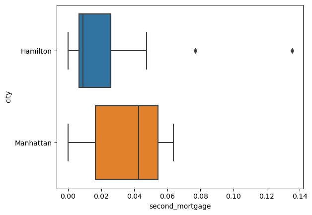

```python
sns.boxplot(data=df_box_city,x='second_mortgage',y='city')
plt.show()
```

Create a boxplot for city and Home Equity

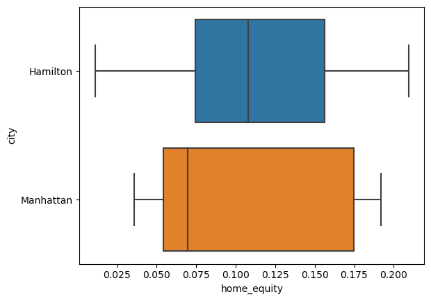

```python
sns.boxplot(data=df_box_city,x='home_equity',y='city')
plt.show()
```

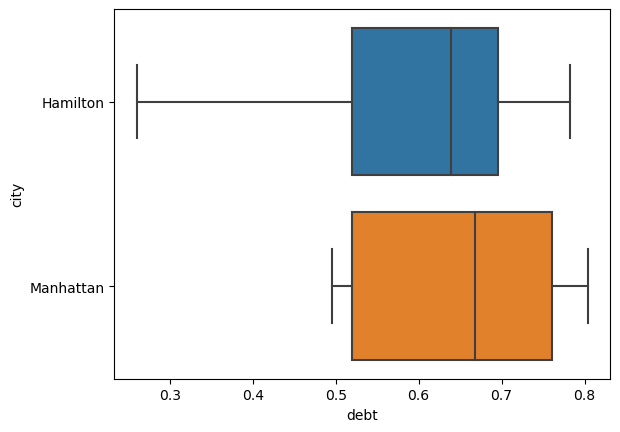

```python
sns.boxplot(data=df_box_city,x='debt',y='city')
plt.show()
```

Create a boxplot for city and Bad Debt

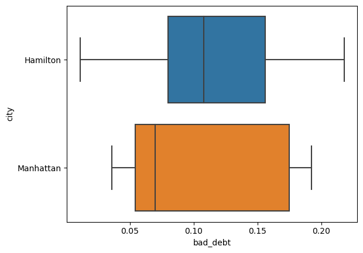

```python
sns.boxplot(data=df_box_city,x='bad_debt',y='city')
plt.show()
```

Create a collated income distribution chart for family income, house hold income, and remaining income

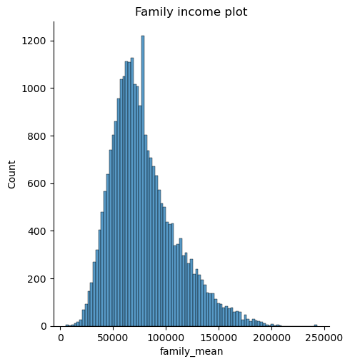

```python
sns.displot(df_train['family_mean'])
plt.title('Family income plot')
```

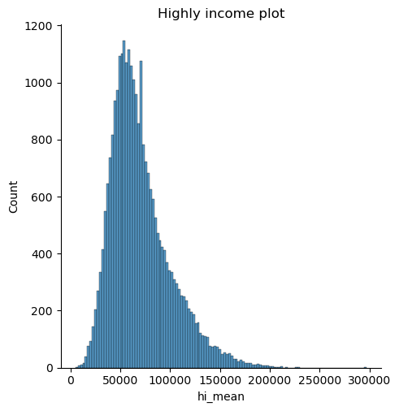

```python
sns.displot(df_train['hi_mean'])
plt.title('Highly income plot')
```

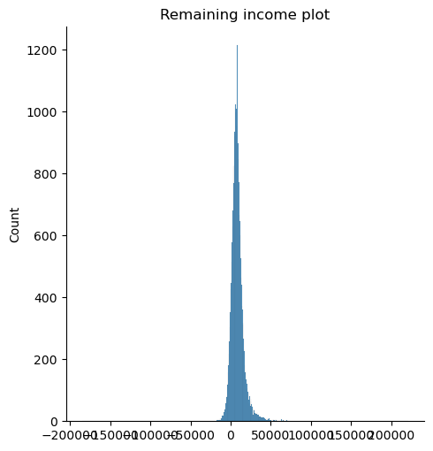

```python
sns.displot(df_train['family_mean']-df_train['hi_mean'])
plt.title('Remaining income plot')
```

## Perform EDA and come out with insights into population density and age. You may have to derive new fields (make sure to weight averages for accurate measurements):

Use pop and ALand variables to create a new field called population density

Use male_age_median, female_age_median, male_pop, and female_pop to create a new field called median age

Visualize the findings using appropriate chart type

```python
df_train.columns
```

```
Index(['COUNTYID', 'STATEID', 'state', 'state_ab', 'city', 'place', 'type',
       'primary', 'zip_code', 'area_code', 'lat', 'lng', 'ALand', 'AWater',
       'pop', 'male_pop', 'female_pop', 'rent_mean', 'rent_median',
       'rent_stdev', 'rent_sample_weight', 'rent_samples', 'rent_gt_10',
       'rent_gt_15', 'rent_gt_20', 'rent_gt_25', 'rent_gt_30', 'rent_gt_35',
       'rent_gt_40', 'rent_gt_50', 'universe_samples', 'used_samples',
       'hi_mean', 'hi_median', 'hi_stdev', 'hi_sample_weight', 'hi_samples',
       'family_mean', 'family_median', 'family_stdev', 'family_sample_weight',
       'family_samples', 'hc_mortgage_mean', 'hc_mortgage_median',
       'hc_mortgage_stdev', 'hc_mortgage_sample_weight', 'hc_mortgage_samples',
       'hc_mean', 'hc_median', 'hc_stdev', 'hc_samples', 'hc_sample_weight',
       'home_equity_second_mortgage', 'second_mortgage', 'home_equity', 'debt',
       'second_mortgage_cdf', 'home_equity_cdf', 'debt_cdf', 'hs_degree',
       'hs_degree_male', 'hs_degree_female', 'male_age_mean',
       'male_age_median', 'male_age_stdev', 'male_age_sample_weight',
       'male_age_samples', 'female_age_mean', 'female_age_median',
       'female_age_stdev', 'female_age_sample_weight', 'female_age_samples',
       'pct_own', 'married', 'married_snp', 'separated', 'divorced',
       'bad_debt'],
      dtype='object')
```

```python
import warnings
warnings.filterwarnings('ignore')
```

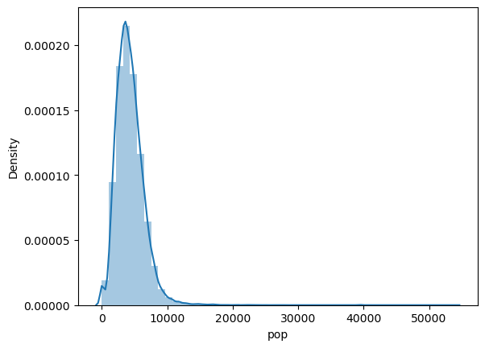

```python
sns.distplot(df_train['pop'])
```

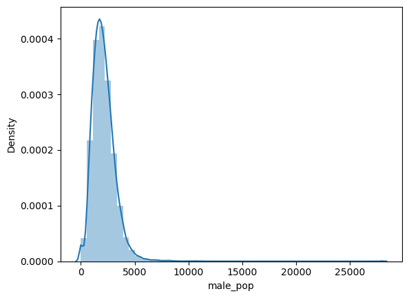

```python
sns.distplot(df_train['male_pop'])
```

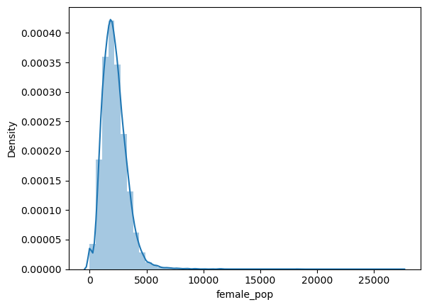

```python
sns.distplot(df_train['female_pop'])
```

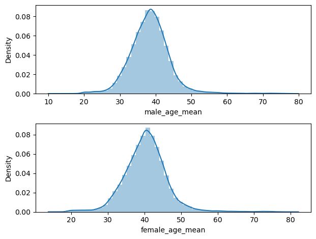

```python
fig,(ax1,ax2)=plt.subplots(2,1)
plt.subplots_adjust(wspace=0.8,hspace=0.9)
sns.distplot(df_train['male_age_mean'],ax=ax1)
sns.distplot(df_train['female_age_mean'],ax=ax2)
plt.tight_layout()
plt.show()
```

## Use pop and AL variables to create a new field called population density

```python
df_train['pop_density']=df_train['pop']/df_train['ALand']
```

```python
df_train['pop_density']
```

```
UID
267822    0.000026
246444    0.001687
245683    0.000099
279653    0.002442
247218    0.002207
            ...
279212    0.002650
277856    0.000818
233000    0.000002
287425    0.000619
265371    0.000478
Name: pop_density, Length: 27321, dtype: float64
```

```python
df_test['pop_density']=df_test['pop']/df_test['ALand']
```

```python
df_test['pop_density']
```

```
UID
255504    0.001260
252676    0.000257
276314    0.000015
248614    0.000005
286865    0.000452
            ...
238088    0.000061
242811    0.008241
250127    0.001415
241096    0.000537
287763    0.002069
Name: pop_density, Length: 11709, dtype: float64
```

Check population density

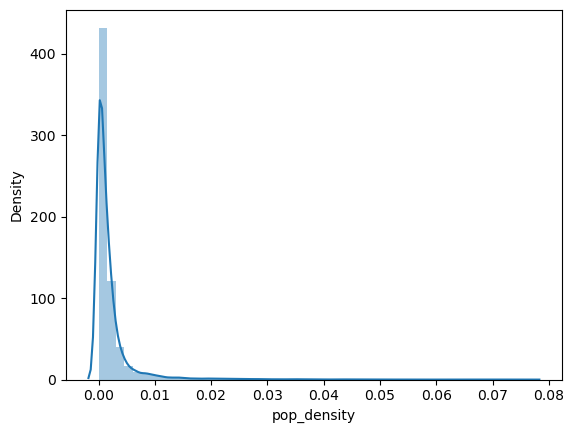

```python
sns.distplot(df_train['pop_density'])
plt.show()
```

Visualize the findings using appropriate chart type

```python
df_train['age_median']=(df_train['male_age_median']+df_train['female_age_median'])/2
df_train['age_median']
```

```
UID
267822    44.666665
246444    34.791665
245683    41.833330
279653    49.750000
247218    22.000000
            ...
279212    40.916670
277856    39.166665
233000    44.166665
287425    45.041670
265371    31.166665
Name: age_median, Length: 27321, dtype: float64
```

```python
df_test['age_median']=(df_test['male_age_median']+df_test['female_age_median'])/2
df_test['age_median']
```

```
UID
255504    30.791665
252676    46.375000
276314    43.208335
248614    45.500000
286865    43.208335
            ...
238088    57.541665
242811    31.333330
250127    39.291670
241096    44.208335
287763    35.208335
Name: age_median, Length: 11709, dtype: float64
```

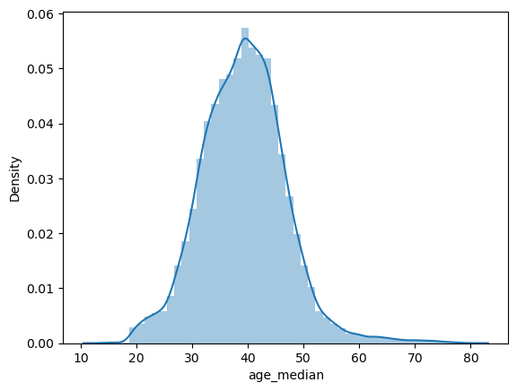

```python
sns.distplot(df_train['age_median'])
plt.show()
```

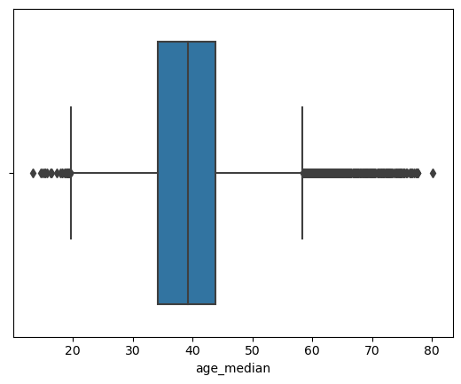

```python
sns.boxplot(df_train['age_median'])
plt.show()
```

## Create bins for population into a new variable by selecting appropriate class interval so that the number of categories don’t exceed 5 for the ease of analysis.

Analyze the married, separated, and divorced population for these population brackets

Visualize using appropriate chart type

```python
df_train['pop_bins']=pd.cut(df_train['pop'],bins=5,labels=['very low','low','medium','high','very high'])
df_train['pop_bins']
```

```
UID
267822    very low
246444    very low
245683    very low
279653    very low
247218    very low
            ...
279212    very low
277856    very low
233000    very low
287425         low
265371    very low
Name: pop_bins, Length: 27321, dtype: category
Categories (5, object): ['very low' < 'low' < 'medium' < 'high' < 'very high']
```

```python
# apply function
def func(num):
    if num<7000:
        return'low'
```

```python
df_train['pop_bin']=df_train['pop'].apply(func)
```

```python
df_train['pop_bins']=pd.cut(df_train['pop'],bins=5,labels=['very low','low','medium','high','very high'])
```

```python
df_train['pop_bins'].value_counts()
```

```
very low     27058
low            246
medium           9
high             7
very high        1
Name: pop_bins, dtype: int64
```

```python
df_train[['pop','pop_bins']].head()
```

| UID | pop | pop_bins |
| --- | --- | --- |
| 267822 | 5230 | very low |
| 246444 | 2633 | very low |
| 245683 | 6881 | very low |
| 279653 | 2700 | very low |
| 247218 | 5637 | very low |

```python
df_train['pop'].describe()
```

```
count    27321.000000
mean      4316.032685
std       2169.226173
min          0.000000
25%       2885.000000
50%       4042.000000
75%       5430.000000
max      53812.000000
Name: pop, dtype: float64
```

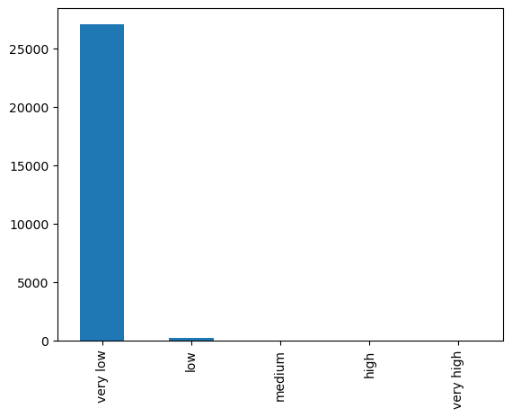

```python
df_train['pop_bins'].value_counts().plot(kind='bar')
```

## Analyze the married, separated, and divorced population for these population brackets

```python
df_train.groupby(by='pop_bins')[['married','separated', 'divorced']].count()
```

| pop_bins | married | separated | divorced |
| --- | --- | --- | --- |
| very low | 27058 | 27058 | 27058 |
| low | 246 | 246 | 246 |
| medium | 9 | 9 | 9 |
| high | 7 | 7 | 7 |
| very high | 1 | 1 | 1 |

```python
df_train.groupby(by='pop_bins')[['married','separated', 'divorced']].agg(['sum','mean','median','count'])
```

| pop_bins | married sum | married mean | married median | married count | separated sum | separated mean | separated median | separated count | divorced sum | divorced mean | divorced median | divorced count |
| --- | --- | --- | --- | --- | --- | --- | --- | --- | --- | --- | --- | --- |
| very low | 13733.22489 | 0.507548 | 0.524680 | 27058 | 517.52126 | 0.019126 | 0.013650 | 27058 | 2719.430721 | 0.100504 | 0.096020 | 27058 |
| low | 143.88385 | 0.584894 | 0.593135 | 246 | 3.89480 | 0.015833 | 0.011195 | 246 | 18.535600 | 0.075348 | 0.070045 | 246 |
| medium | 5.90163 | 0.655737 | 0.618710 | 9 | 0.04503 | 0.005003 | 0.004120 | 9 | 0.593340 | 0.065927 | 0.064890 | 9 |
| high | 3.52351 | 0.503359 | 0.335660 | 7 | 0.05699 | 0.008141 | 0.002500 | 7 | 0.273210 | 0.039030 | 0.010320 | 7 |
| very high | 0.73474 | 0.734740 | 0.734740 | 1 | 0.00405 | 0.004050 | 0.004050 | 1 | 0.030360 | 0.030360 | 0.030360 | 1 |

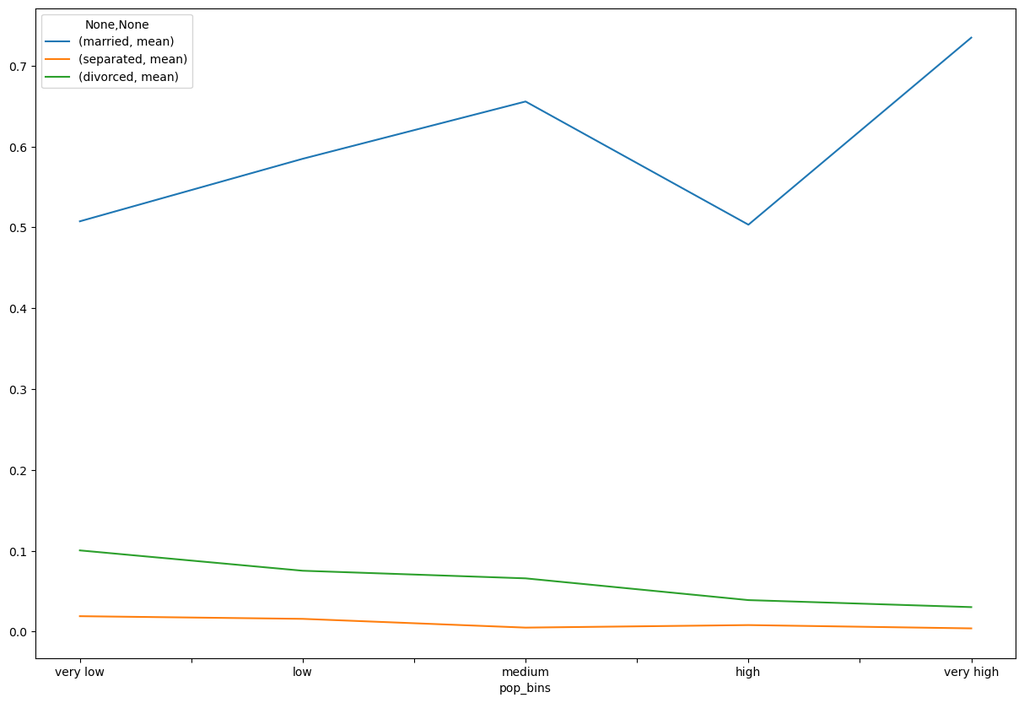

```python
df_train.groupby(by='pop_bins')[['married','separated', 'divorced']].agg(['mean']).plot(figsize=(15,10))
```

## Please detail your observations for rent as a percentage of income at an overall level, and for different states.

```python
rent_state_mean=df_train.groupby(by='state')['rent_mean'].agg(["mean"])
rent_state_mean
```

| state | mean |
| --- | --- |
| Alabama | 774.004927 |
| Alaska | 1185.763570 |
| Arizona | 1097.753511 |
| Arkansas | 720.918575 |
| California | 1471.133857 |
| Colorado | 1198.191514 |
| Connecticut | 1317.100534 |
| Delaware | 1127.309811 |
| District of Columbia | 1417.097934 |
| Florida | 1141.758549 |
| Georgia | 964.575973 |
| Hawaii | 1710.629412 |
| Idaho | 800.486650 |
| Illinois | 1034.887921 |
| Indiana | 810.910355 |
| Iowa | 737.246152 |
| Kansas | 831.215856 |
| Kentucky | 742.199763 |
| Louisiana | 846.375506 |
| Maine | 829.941899 |
| Maryland | 1412.009565 |
| Massachusetts | 1211.811159 |
| Michigan | 928.123200 |
| Minnesota | 957.376502 |
| Mississippi | 738.111770 |
| Missouri | 829.011192 |
| Montana | 776.337306 |
| Nebraska | 835.165893 |
| Nevada | 1128.641766 |
| New Hampshire | 1083.090073 |
| New Jersey | 1379.709933 |
| New Mexico | 853.611858 |
| New York | 1248.850743 |
| North Carolina | 885.593430 |
| North Dakota | 771.423137 |
| Ohio | 820.004760 |
| Oklahoma | 777.702422 |
| Oregon | 1024.616948 |
| Pennsylvania | 949.580140 |
| Puerto Rico | 550.079459 |
| Rhode Island | 1039.482069 |
| South Carolina | 859.919160 |
| South Dakota | 685.325569 |
| Tennessee | 856.649930 |
| Texas | 977.074993 |
| Utah | 1068.930520 |
| Vermont | 937.119939 |
| Virginia | 1305.707687 |
| Washington | 1126.649264 |
| West Virginia | 667.193267 |
| Wisconsin | 841.670190 |
| Wyoming | 861.395327 |

```python
income_state_mean=df_train.groupby(by='state')['family_mean'].agg(["mean"])
```

```python
income_state_mean.head()
```

| state | mean |
| --- | --- |
| Alabama | 67030.064213 |
| Alaska | 92136.545109 |
| Arizona | 73328.238798 |
| Arkansas | 64765.377850 |
| California | 87655.470820 |

```python
# calculate rent percentage
rent_perc=rent_state_mean['mean']/income_state_mean['mean']
```

```python
rent_perc.head()
```

```
state
Alabama       0.011547
Alaska        0.012870
Arizona       0.014970
Arkansas      0.011131
California    0.016783
Name: mean, dtype: float64
```